# Columbia Basin DART Fish Passage

Allison Horst

2022-03-02

## Overview

The purpose of this project is to explore, by project and year, adult fish passage recorded at dams in the Columbia Basin using data from [Columbia River DART (Data Access in Real Time)](http://www.cbr.washington.edu/dart).

Using a combination of web scraping, data wrangling, analysis and visualization, I explore trends in fish passage using long term time series data for fish counts.

## 1. Access the data

### Scrape DART project website to get site abbreviations

Since I’ll be looping over URLs using site abbreviations, first I use `rvest::read_html()` and `rvest::html_table()` to scrape the page, then access the table. A bit of cleaning with `janitor::clean_names()` and `dplyr::pull()` and I have a vector of project abbreviations stored in `project_abb`.

```r
# Get the site abbreviations
# Scrape information on projects (from URL below)
scrape_projects <- rvest::read_html("http://www.cbr.washington.edu/dart/metadata/adult")
projects_tbl <- rvest::html_table(scrape_projects) %>%
  purrr::flatten_df() %>%
  janitor::clean_names()

# Create vector of project abbreviations
project_abb <- projects_tbl %>%
   pull(abbrev)

# Check it out:
project_abb
```

```
##  [1] "WFF" "BON" "LYL" "TDA" "JDA" "MCN" "IHR" "LMN" "LGS" "LWG" "PRO" "ROZ"
## [13] "PRD" "WAN" "RIS" "TUM" "RRH" "WEL" "ZOS"
```

### Create automated query URLs

Rather that submitting individual queries for each site and year, which would be nothing short of a complete bummer, I’ll paste information into a URL template so that I can access information using those URLs.

Here is an example of a query link that is for site “BON” (Bonneville Dam), for the year 2019: http://www.cbr.washington.edu/dart/cs/php/rpt/adult_daily.php?sc=1&outputFormat=html&year=2019&proj=BON&span=no&startdate=1%2F1&enddate=12%2F31&run=&syear=2019&eyear=2019

Note where the year (2019) and project abbreviation (BON) show up - we’ll make those generic placeholders in our query URL template, so that we can automatically loop through years and projects to automatically create the query URLs for each combination.

```r
# Create a sequence of years
years <- seq(from = 1939, to = 2021, by = 1)

# Initiate an empty vector (where the URLs will be put)
url_out <- matrix(nrow = length(years), ncol = length(project_abb))

# Loop over the years and project abbreviations to create a query URL for each combination:

query_urls <- for (i in seq_along(years)) {
  for (j in seq_along(project_abb)) {
  url_out[i,j] <- paste0("http://www.cbr.washington.edu/dart/cs/php/rpt/adult_daily.php?sc=1&outputFormat=html&year=", years[i], "&proj=", project_abb[j], "&span=no&startdate=1%2F1&enddate=12%2F31&run=&syear=", years[i], "&eyear=", years[i])
  }
}
```

Then just a bit more cleaning on the output data frame containing the query URLs:

```r
# Convert matrix to a data frame
url_clean <- url_out %>%
  as.data.frame()

# Update column names to project abbreviation
names(url_clean) <- project_abb

# Add year to output (and convert to data frame)
url_clean <- data.frame(years, url_clean)

# Reshape to long format
url_long <- url_clean %>%
  tidyr::pivot_longer(cols = 2:ncol(url_clean),
                      names_to = "project",
                      values_to = "query_url")
```

Which returns a really nice data frame containing the query URL for each year/project combination (first 5 lines shown below):

| years | project | query_url |
| --- | --- | --- |
| 1939 | WFF | http://www.cbr.washington.edu/dart/cs/php/rpt/adult_daily.php?sc=1&outputFormat=html&year=1939&proj=WFF&span=no&startdate=1%2F1&enddate=12%2F31&run=&syear=1939&eyear=1939 |
| 1939 | BON | http://www.cbr.washington.edu/dart/cs/php/rpt/adult_daily.php?sc=1&outputFormat=html&year=1939&proj=BON&span=no&startdate=1%2F1&enddate=12%2F31&run=&syear=1939&eyear=1939 |
| 1939 | LYL | http://www.cbr.washington.edu/dart/cs/php/rpt/adult_daily.php?sc=1&outputFormat=html&year=1939&proj=LYL&span=no&startdate=1%2F1&enddate=12%2F31&run=&syear=1939&eyear=1939 |
| 1939 | TDA | http://www.cbr.washington.edu/dart/cs/php/rpt/adult_daily.php?sc=1&outputFormat=html&year=1939&proj=TDA&span=no&startdate=1%2F1&enddate=12%2F31&run=&syear=1939&eyear=1939 |
| 1939 | JDA | http://www.cbr.washington.edu/dart/cs/php/rpt/adult_daily.php?sc=1&outputFormat=html&year=1939&proj=JDA&span=no&startdate=1%2F1&enddate=12%2F31&run=&syear=1939&eyear=1939 |

### Loop over the URLs and scrape the data table

Now we have an automated list of URLs for each possible year and project combination. We want to loop over each, scraping the data table that is produced for every URL. **Note:** Not all projects have data for all years, so I use the `purrr::possibly()` function here to skip if the URL doesn’t have a table element.

```r
# Function to get the table from each URL, then do a bit of cleaning:
get_data <- function(url_only) {
    url_only %>%
    read_html() %>%
    html_table() %>%
    flatten_df()
}

# Possibly to pass over empty URLs
get_data_possibly <- possibly(get_data, otherwise = NULL)

# Loop over all URLs, then combine all table outputs by row with `purrr::map_dfr()``
dart_data <- map_dfr(url_only, get_data_possibly)

# Write the output as a .csv for storage
write_csv(x = dart_data, file = "dart_data.csv")
```

### Read in the CSV

Read in the data as `fish_passage` and do some wrangling for easier work & analysis later on:

```r
fish_passage <- read_csv("dart_data.csv") %>%
  janitor::row_to_names(row_number = 1) %>%
  janitor::clean_names() %>%
  filter(!date %in% c("Date", "Total")) %>% # Omit totals / summary rows
  pivot_longer(cols = chinook:pink, names_to = "species", values_to = "adult_count") %>%  # Get into tidy format
  mutate(date = lubridate::ymd(date),
         adult_count = as.numeric(adult_count),
         temp_c = as.numeric(temp_c)) %>% # Convert date to class Date
  mutate(day = lubridate::day(date),
         month = as.factor(lubridate::month(date)),
         year = as.integer(lubridate::year(date)),
         week = as.integer(lubridate::week(date)))
```

### Take a glimpse:

```r
glimpse(fish_passage)
```

```
## Rows: 2,825,208
## Columns: 10
## $ project     <chr> "Bonneville", "Bonneville", "Bonneville", "Bonneville", "B…
## $ date        <date> 1939-01-01, 1939-01-01, 1939-01-01, 1939-01-01, 1939-01-0…
## $ chinook_run <chr> NA, NA, NA, NA, NA, NA, NA, NA, NA, NA, NA, NA, NA, NA, NA…
## $ temp_c      <dbl> NA, NA, NA, NA, NA, NA, NA, NA, NA, NA, NA, NA, NA, NA, NA…
## $ species     <chr> "chinook", "jack_chinook", "steelhead", "wild_steelhead", …
## $ adult_count <dbl> NA, NA, NA, NA, NA, NA, NA, NA, NA, NA, NA, NA, NA, NA, 1,…
## $ day         <int> 1, 1, 1, 1, 1, 1, 1, 1, 1, 1, 1, 1, 2, 2, 2, 2, 2, 2, 2, 2…
## $ month       <fct> 1, 1, 1, 1, 1, 1, 1, 1, 1, 1, 1, 1, 1, 1, 1, 1, 1, 1, 1, 1…
## $ year        <int> 1939, 1939, 1939, 1939, 1939, 1939, 1939, 1939, 1939, 1939…
## $ week        <int> 1, 1, 1, 1, 1, 1, 1, 1, 1, 1, 1, 1, 1, 1, 1, 1, 1, 1, 1, 1…
```

We see the resulting 10 variables in `fish_passage` are:

- `project`: the project / location name
- `date`: date of the fish count
- `chinook_run`: season, as applicable
- `temp_c`: temperature (celsius)
- `species`: fish species
- `adult_count`: count of adults passing that project on that day
- `day`, `month`, `year` and `week`: parsed numeric day, month, year and week information

## 2. Initial data exploration

For some initial exploration I’ll just checkout steelhead passage at Bonneville Dam.

```r
bon_steelhead <- fish_passage %>%
  filter(species == "steelhead", project == "Bonneville")

bon_steelhead_weekly <- bon_steelhead%>%
  group_by(year, week) %>%
  summarize(fish_count = sum(adult_count, na.rm = TRUE))
```

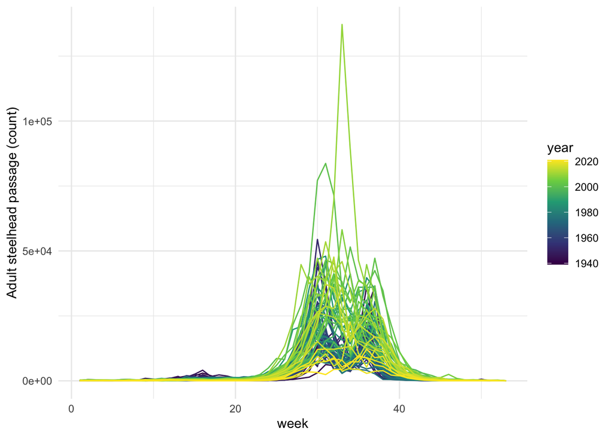

```r
ggplot(data = bon_steelhead_weekly,
       aes(x = week,
           y = fish_count,
           group = year)) +
  geom_line(aes(color = year), size = 0.5) +
  scale_color_viridis_c() +
  theme_minimal() +
  labs(x = "week", y = "Adult steelhead passage (count)")
```

It looks like there may be changing patterns over time, but the season plot with all years together doesn’t make this clear. I’ll break this down a bit further to look into differences across decades.

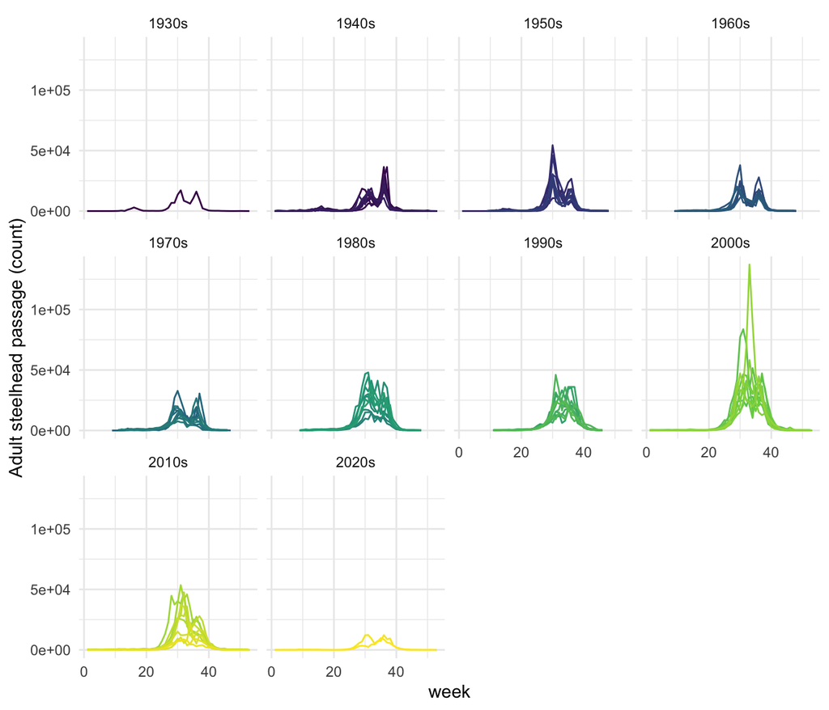

```r
bon_steelhead_decades <- bon_steelhead_weekly %>%
  mutate(decade = floor(year / 10) * 10,
         decade = paste0(decade, "s")) # Add decade

ggplot(data = bon_steelhead_decades,
       aes(x = week,
           y = fish_count,
           group = year)) +
  geom_line(aes(color = year), size = 0.5, show.legend = FALSE) +
  scale_color_viridis_c() +
  theme_minimal() +
  labs(x = "week", y = "Adult steelhead passage (count)") +
  facet_wrap(~decade)
```

Generally, it looks like the clear bimodal passage we see in earlier decades becomes murkier (and possibly unimodal) in more recent decades. It also looks like an earlier (spring) peak seen in earlier decades (1930’s - 1950’s), though minor compared to the fall passage, is nonexistent starting in the 1960s.

### Total annual fish counts by species and project

Here, I’ll visualize three salmon species (Chinook, Sockeye, Steelhead) over time, by project.

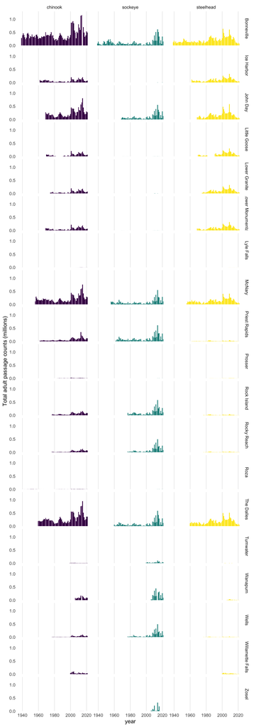

```r
annual_counts <- fish_passage %>%
  group_by(year, project, species) %>%
  summarize(total_fish = sum(adult_count, na.rm = TRUE)) %>%
  mutate(total_fish_millions = total_fish / 1e6) %>%
  filter(species %in% c("chinook", "sockeye", "steelhead"
  ))

ggplot(data = annual_counts, aes(x = year, y = total_fish_millions)) +
  geom_col(aes(fill = species), show.legend = FALSE) +
  scale_fill_viridis_d() +
  facet_grid(project ~ species) +
  theme_minimal() +
  labs(y = "Total adult passage counts (millions)") +
  scale_y_continuous(limits = c(0, 1.3),
                     breaks = c(0, 0.5, 1),
                     expand = c(0,0)) +
  theme(panel.grid.minor = element_blank(),
        panel.grid.major.y = element_blank())
```